# Case Study 1

Victor Yim

October 29, 2016

## Introduction

There are many ways to measure and compare economy between countries. The most typical statistics used are either GDP or Income.  
The gross domestic product (GDP) is a unit measure of total values of the final output of the goods and services produced in a year. The strength of an economy is often measure in GDP and compare year over year to understand growth. Since this is the total output by a country, there are other variables like population, natural resources, political and other external factors that may impact whether countries have high GDP. Average Income is another method to measure strength and prosperity of an economy. Countries with higher income can typically afford more goods and services, thus in turn create a stronger economy. As like GDP, there are other factors that could impact this measure. For this analysis, we attempt to look at the two types for measure to evaluate their relationship.

R codes below explain each of the steps taken to generate the result

```r
# first setting the directory for the download
setwd("C:/Users/Victor Yim/Documents/SMU/6306/Case Study 1")
# Download data using repmis library
library(repmis)
FinURL1<-"https://d396qusza40orc.cloudfront.net/getdata%2Fdata%2FGDP.csv"
GDP <- repmis::source_data(FinURL1, sep = ",", skip=3, header = TRUE)
```

```
## SHA-1 hash of the downloaded data file is:
## 18dd2f9ca509a8ace7d8de3831a8f842124c533d
```

```r
#Tidy data process
#rename column headers to reflect field values
names(GDP) [1]<-("country")
names(GDP)[5]<-("GDP")
#subsetting data to remove columns with no value
GDP2012<-subset(GDP, country>0, select = c(country, Ranking,Economy,GDP))
#Continue tidy data to reflect actual data characteristics
GDP2012$Ranking<-as.numeric(GDP2012$Ranking)
GDP2012$GDP<-as.numeric(gsub(",","",GDP2012$GDP))
#examine data
head(GDP2012)
```

```
##   country Ranking        Economy      GDP
## 2     USA       1  United States 16244600
## 3     CHN       2          China  8227103
## 4     JPN       3          Japan  5959718
## 5     DEU       4        Germany  3428131
## 6     FRA       5         France  2612878
## 7     GBR       6 United Kingdom  2471784
```

```r
#obtain second dataset for income
FinURL2<-"https://d396qusza40orc.cloudfront.net/getdata%2Fdata%2FEDSTATS_Country.csv"
EDU <- repmis::source_data(FinURL2, sep = ",",  header = TRUE)
```

```
## SHA-1 hash of the downloaded data file is:
## 20be6ae8245b5a565a815c18a615a83c34745e5e
```

```r
#rename column variable to match first dataset
names(EDU) [1]<-("country")
#examine data
head(EDU)
```

```
##   country                    Long Name         Income Group
## 1     ABW                        Aruba High income: nonOECD
## 2     ADO      Principality of Andorra High income: nonOECD
## 3     AFG Islamic State of Afghanistan           Low income
## 4     AGO  People's Republic of Angola  Lower middle income
## 5     ALB          Republic of Albania  Upper middle income
## 6     ARE         United Arab Emirates High income: nonOECD
##                       Region Lending category Other groups  Currency Unit
## 1  Latin America & Caribbean                                Aruban florin
## 2      Europe & Central Asia                                         Euro
## 3                 South Asia              IDA         HIPC Afghan afghani
## 4         Sub-Saharan Africa              IDA              Angolan kwanza
## 5      Europe & Central Asia             IBRD                Albanian lek
## 6 Middle East & North Africa                                U.A.E. dirham
##   Latest population census  Latest household survey
```

[output cut: 83 more lines]

# Questions on Merged Data

1. Merge the data based on the country shortcode. How many of the IDs match?

```r
#merging GDP an EDU dataset from worldbank
total.data <- merge(GDP2012,EDU,by="country")
dim(total.data)
```

```
## [1] 224  34
```

There are 224 matches between the 2 datasets

2. Sort the data frame in ascending order by GDP (so United States is last). What is the 13th country in the resulting data frame?

```r
total.data2<-subset(total.data,  select = c(country, Ranking,Economy,GDP))
The13th<-total.data2[order(total.data$GDP),]
head(The13th, n=13)
```

```
##     country Ranking                        Economy GDP
## 204     TUV     190                         Tuvalu  40
## 105     KIR     189                       Kiribati 175
## 132     MHL     188               Marshall Islands 182
## 161     PLW     187                          Palau 228
## 185     STP     186          São Tomé and Principe 263
## 68      FSM     185          Micronesia, Fed. Sts. 326
## 200     TON     184                          Tonga 472
## 51      DMA     183                       Dominica 480
## 42      COM     182                        Comoros 596
## 219     WSM     181                          Samoa 684
## 212     VCT     180 St. Vincent and the Grenadines 713
## 78      GRD     178                        Grenada 767
## 106     KNA     178            St. Kitts and Nevis 767
```

there are 2 countries tied for 13: Grenada and St. Kitts and Nevis

3. What are the average GDP rankings for the “High income: OECD” and “High income:##nonOECD” groups?

```r
#tidy data process to remove commas
colnames(total.data) <- gsub(" ","",colnames(total.data))
HIC<-subset(total.data,  select = c(country, Ranking,Economy,GDP,IncomeGroup))
HIC$IncomeGroup<-gsub(" ","",HIC$IncomeGroup)
HIC$IncomeGroup<-gsub(":","",HIC$IncomeGroup)
#subsetting only data with high income
HICOECD<-subset(HIC, IncomeGroup=="HighincomenonOECD" | IncomeGroup=="HighincomeOECD" , NA.RM=TRUE,  select = c(GDP, country, IncomeGroup))
aggregate( GDP~IncomeGroup, HICOECD, mean )
```

```
##         IncomeGroup       GDP
## 1 HighincomenonOECD  104349.8
## 2    HighincomeOECD 1483917.1
```

The Average GDP for HighincomenonOECD = 104349.8 and the Average GDP for HighincomeOECD = 1483917.1

4. Plot the GDP for all of the countries. Use ggplot2 to color your plot by Income Group.

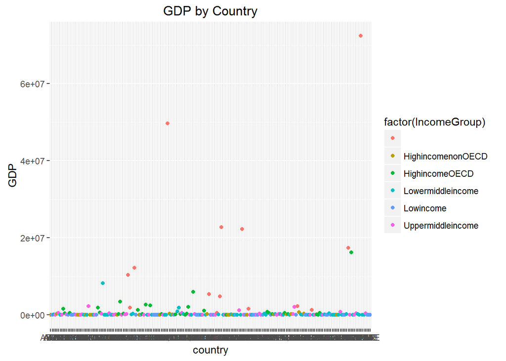

```r
library(ggplot2)
HICGRAPH<-subset(HIC, NA.RM=TRUE, GDP>1,  select = c(GDP, country, IncomeGroup))
HICGRAPH2<-HICGRAPH[complete.cases(HICGRAPH),]
#qplot(x, y, data=, color=, shape=, size=, alpha=, geom=, method=, formula=, facets=, xlim=, ylim= xlab=, ylab=, main=, sub=)
qplot(country, GDP, data=HICGRAPH2, color=factor(IncomeGroup),  main='GDP by Country')
```

5. Cut the GDP ranking into 5 separate quantile groups. Make a table versus Income.Group. How many countries are Lower middle income but among the 38 nations with highest GDP?

```r
library(dplyr)
HIC$quantile <- ntile(HIC$GDP, 5)
attach(HIC)
Pivottabletable <- table(IncomeGroup, quantile)
detach(HIC)

Pivottabletable
```

```
##                    quantile
## IncomeGroup          1  2  3  4  5
##                      0  0  0  2 12
##   HighincomenonOECD  4  7  7  5  0
##   HighincomeOECD     0  1  5 17  7
##   Lowermiddleincome 17 10 17  8  2
##   Lowincome         13 19  5  0  0
##   Uppermiddleincome 11  8 11 13  2
```